# Week 07 Day 01

## Student Questions

- What’s the difference between the parameter $\theta$ and the parameter space $\Omega$?

$$\Omega = \{\mu : 0 \leq \mu \leq
4\}$$
$$\Omega = \{p : 0 \leq p \leq
1\}$$

- What’s the difference between a point estimate and a point estimator?
  - Estimand, estimator, estimate
  - Recall difference between $X$ and $x$ in 361
- What does maximum likelihood do / what’s it for?
  - We don’t know the value of a parameter $\theta$, but we do have observed data $x_1, x_2, ... x_n$. There’s many possible values of $\theta$. Which value maximizes the likelihood that we’d observe the $x_1, x_2, ... x_n$ we observed?
- Quick review of independence / a random sample of $n$ random variables (see Knowlege Check Q below)
- Let $X_1, X_2, ... X_n$ be a random sample from a distribution that depends on one or more unknown parameters, $\theta_1, \theta_2, ... \theta_m$.
  - Why would the parameters go to $m$ but the $X$’s only go to $n$? Wouldn’t there be the same number of parameters as Xs?
  - [Seeing Theory resource](https://seeing-theory.brown.edu/probability-distributions/index.html#section2)
- Where did the summation notation come from in the likelihood function for the normal distribution?
- What do they mean by “competing estimators”? Does that mean that we have to decide which is “unbiased” for each problem that we do or just for each parameter?
- What type of bias are we talking about when we say “unbiased estimator”?

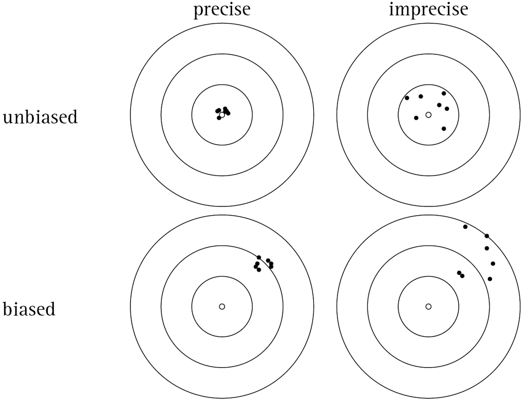

- If this method (MLE) isn’t guaranteed to give us unbiased estimators, is it really the best method for getting estimators? Are there better methods?
  - A few nice properties of MLE (proofs mostly beyond the scope of this course - potential special topics!):
    - Consistency: the estimator converges in probability to the thing being estimated (see probability theory: Weak Law of Large Numbers)
    - Functional equivariance: If $\hat{\theta}$ is the maximum likelihood estimator for $\theta$, and if $g(\theta)$ is any transformation of $\theta$, then the maximum likelihood estimator for $\alpha = g(\theta)$ is $\hat{\alpha} = g(\hat{\theta})$
    - Efficiency: achieves the Cramer-Rao lower bound, meaning there is no consistent estimator that has lower MSE (mean squared error = $Bias(\hat{\theta}^2) + V(\hat{\theta})$
  - Alternatives to MLE: Method of Moments, RMLE, Bayesian estimation

## In-class practice

- In groups, do a “down-the-line” proof for the derivation of $\hat{p} = \frac{\sum_{i = 1}^n X_i}{n}$ as the MLE of the proportion $p$. See Example 1-1

## Knowledge Check

- Suppose that for a random sample $X_1, X_2, ..., X_n$, each $X_i$ has pdf $f(x_i; \theta)$, where $\theta$ is an unknown parameter that the pdf depends on (e.g. $\mu$ or $\sigma^2$). Explain what is meant by each piece of the following and how to get from one expression to the next:

$$L(\theta) = P(X_1 = x_1, X_2 = x_2, ...
X_n = x_n) = f(x_1; \theta)\cdot f(x_2;\theta)\cdots f(x_n; \theta) =
\prod_{i = 1}^nf(x_i;\theta)$$

- What are the key features of a Bernoulli random variable?
- What is the pdf of a Bernoulli random variable?
- What is the pdf of a normal random variable?
- In a normal distribution, what notation do we typically use for the parameters $\theta_1$ and $\theta_2$?